# Descriptive statistics

Describing distributions: centre and spread

Dr Massimiliano Canzi

# Distributions

`Did you know:` tardigrades are animals about 0.5 mm long, with eight stubby legs. The German pastor J.A.E. Goeze first described them in 1773 and called them *kleiner Wasserbär*: “little water bear”.

*Source: National Geographic*

## Why describe?

A data set with 344 penguins is too much to take in at once. A descriptive statistic summarises it in one number, such as a typical value or how much the values vary.

Like a map, a summary leaves most of the detail out. Today is about choosing a good summary, and noticing when it hides something important.

## Today

- What a distribution is: empirical and theoretical
- Measures of central tendency: mean, median, mode
- Measures of spread: standard deviation, MAD, range, quantiles
- When each map misleads: skew, outliers, more than one peak
- Grouped summaries and plots, building on `{dplyr}`

## Distributions

A distribution shows how often each value, or range of values, occurs.

- An empirical distribution describes the values we actually observed
- A theoretical distribution is a mathematical shape, fully described by a few numbers called parameters

We compare the two all the time: does our sample look like a shape we know?

## Plotting with `{ggplot2}`

Last week’s promise: `{ggplot2}` builds a plot in layers, added with `+`.

```r
ggplot(data, aes(x = column)) +   # the data, and which column goes where
  geom_histogram() +              # how to draw it
  labs(x = "Axis label")          # labels
```

- `ggplot()` and `aes()` say which data to use and which column goes on `x`, `y` or `colour`
- A `geom_*()` draws the shapes: `geom_histogram()`, `geom_point()`, `geom_boxplot()`
- `labs()` and `theme()` change the labels and the look

Our slides use a theme set up in the hidden first chunk of the .Rmd: your plots will look different, but show the same data.

## An empirical distribution

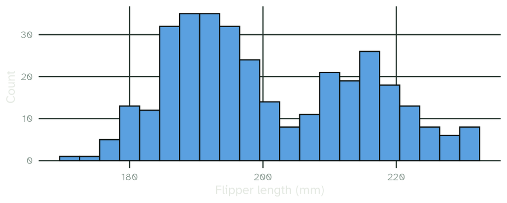

```r
ggplot(penguins, aes(x = flipper_length_mm)) +
  geom_histogram(binwidth = 3, fill = "#5aa0e0", colour = "#0b110e") +
  labs(x = "Flipper length (mm)", y = "Count")
```

Each bar counts the penguins whose flipper length falls in a 3 mm bin.

## Histogram or density?

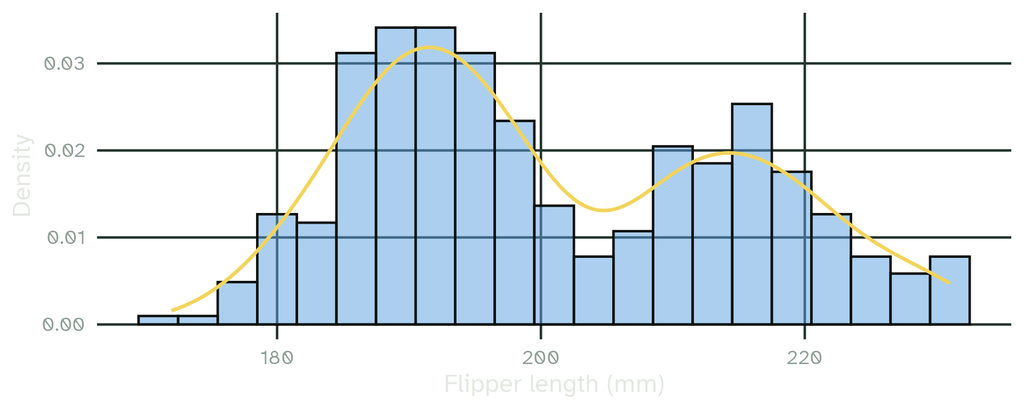

```r
ggplot(penguins, aes(x = flipper_length_mm)) +
  geom_histogram(aes(y = after_stat(density)), binwidth = 3,
                 fill = "#5aa0e0", colour = "#0b110e", alpha = 0.5) +
  geom_density(colour = "#f2d45c", linewidth = 1.2) +
  labs(x = "Flipper length (mm)", y = "Density")
```

The density curve is a smoothed histogram. The area under it is 1.

## The normal distribution

In a normal (or Gaussian) distribution, values are spread symmetrically around the mean, and most of them lie close to it: the familiar bell shape.

Two parameters describe it completely: the mean and the standard deviation.

```r
set.seed(42)    # same random numbers every time we knit
normal <- rnorm(500, mean = 0, sd = 1)
head(round(normal, 2))
```

```
[1]  1.37 -0.56  0.36  0.63  0.40 -0.11
```

## Sample vs theory

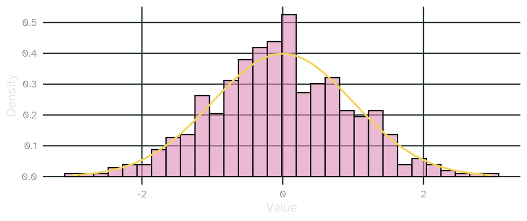

```r
tibble(value = normal) |>
  ggplot(aes(x = value)) +
  geom_histogram(aes(y = after_stat(density)), bins = 30,
                 fill = "#e08ab8", colour = "#0b110e", alpha = 0.6) +
  stat_function(fun = dnorm, colour = "#f2d45c", linewidth = 1.2) +
  labs(x = "Value", y = "Density")
```

Bars: our 500 random values. Line: the theoretical normal curve.

## The 68–95–99.7 rule

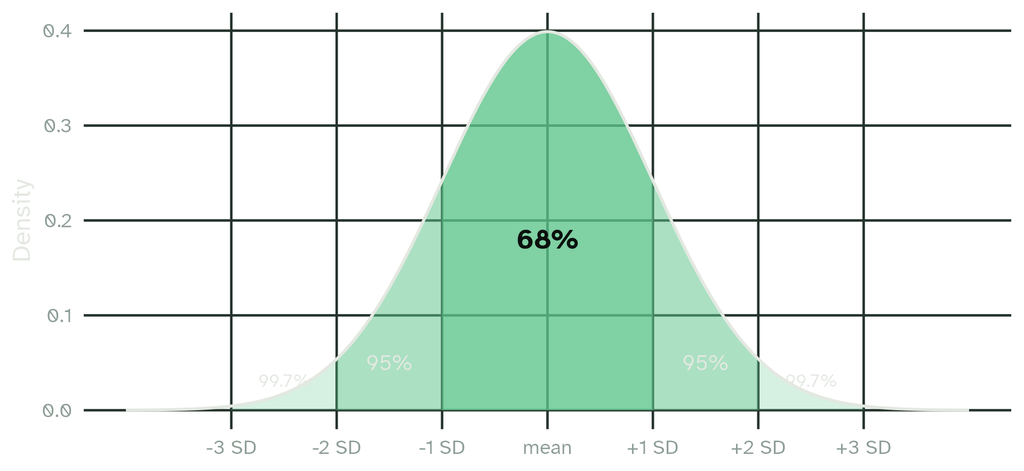

In a normal distribution, about 68% of values lie within 1 SD of the mean, 95% within 2 SD, 99.7% within 3 SD.

## Other distributions

Not every variable is normal. Three shapes you will meet in linguistic data:

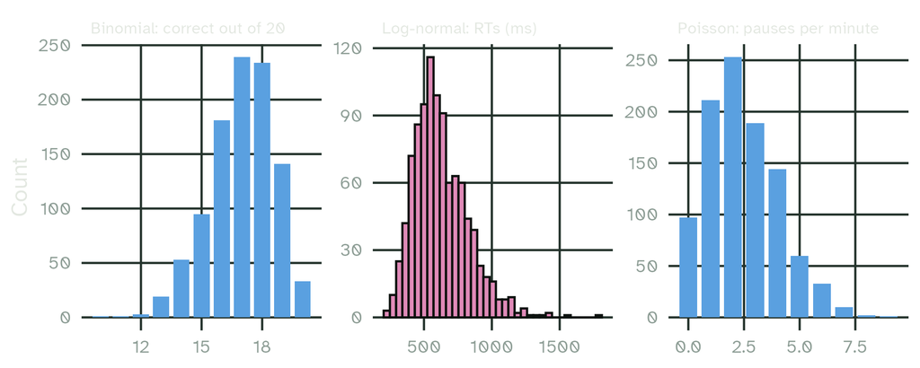

Accuracy out of a fixed number of trials is binomial (lecture 12). Counts of events, such as pauses per minute, are often Poisson. Reaction times and durations are positive with a long right tail, closer to a log-normal or gamma shape.

# Central tendency

`Did you know:` a protein found only in tardigrades, Dsup, protects DNA from radiation. Human cells given the gene for it showed about 40% less DNA damage after X-rays.

*Source: Hashimoto et al. (2016), Nature Communications*

## The tools of the trade

Descriptive measures come in two kinds:

| Central tendency | Spread |
| --- | --- |
| `mean()` | `sd()`, `var()` |
| `median()` | `mad()`, `IQR()` |
| mode | `range()`, `quantile()` |

Always report one of each: a measure of centre and a measure of spread.

## First: missing values

```r
mean(penguins$bill_length_mm)
```

```
[1] NA
```

```r
mean(penguins$bill_length_mm, na.rm = TRUE)
```

```
[1] 43.92193
```

`NA` means “unknown”. The mean of numbers that include an unknown is unknown, unless you tell R to drop them.

Three ways to drop missing values, three different data sets:

```r
nrow(penguins)                               # all rows
```

```
[1] 344
```

```r
nrow(drop_na(penguins, bill_length_mm))      # NA in bill length only
```

```
[1] 342
```

```r
nrow(na.omit(penguins))                      # NA in any column
```

```
[1] 333
```

## `na.omit()` changes your result

```r
mean(penguins$bill_length_mm, na.rm = TRUE)   # 342 penguins
```

```
[1] 43.92193
```

```r
mean(na.omit(penguins)$bill_length_mm)        # 333 penguins
```

```
[1] 43.99279
```

`na.omit()` also dropped 9 penguins with a known bill length but unknown `sex`.

Rule of thumb: drop `NA`s only in the columns you are analysing, with `na.rm = TRUE` or `drop_na(column)`.

## `mean()`

The mean is the sum of all values divided by their number

x = (x₁ + x₂ + … + xₙ) / n

```r
x <- c(4, 8, 15, 16, 23, 42)
sum(x) / length(x)
```

```
[1] 18
```

```r
mean(x)
```

```
[1] 18
```

## `mean()`

```r
penguins |>
  summarise(mean_bill = mean(bill_length_mm, na.rm = TRUE))
```

```
# A tibble: 1 × 1
  mean_bill
      <dbl>
1      43.9
```

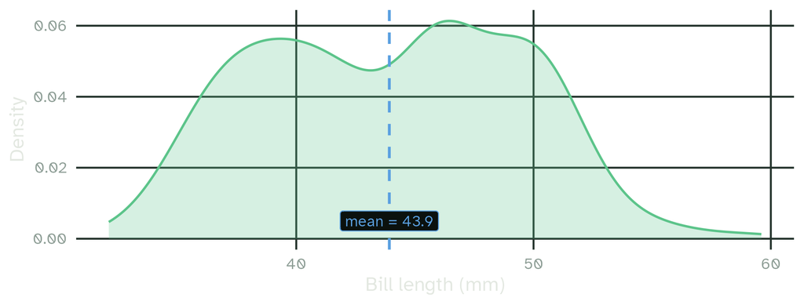

## `median()`

The median is the middle value once all values are sorted from lowest to highest: half the values lie below it, half above.

```r
median(c(3, 1, 5))        # sorted: 1 3 5
```

```
[1] 3
```

```r
median(c(3, 1, 5, 7))     # sorted: 1 3 5 7 -> mean of 3 and 5
```

```
[1] 4
```

With an even number of values, the median is the mean of the two middle values.

## `median()`

```r
penguins |>
  summarise(mean_bill   = mean(bill_length_mm, na.rm = TRUE),
            median_bill = median(bill_length_mm, na.rm = TRUE))
```

```
# A tibble: 1 × 2
  mean_bill median_bill
      <dbl>       <dbl>
1      43.9        44.4
```

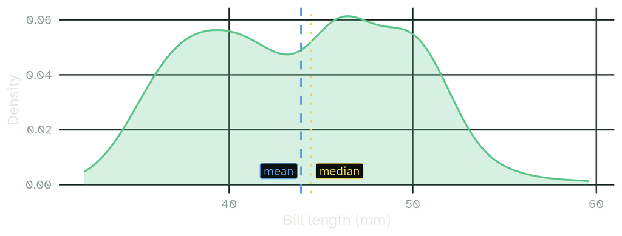

## One number can hide a lot

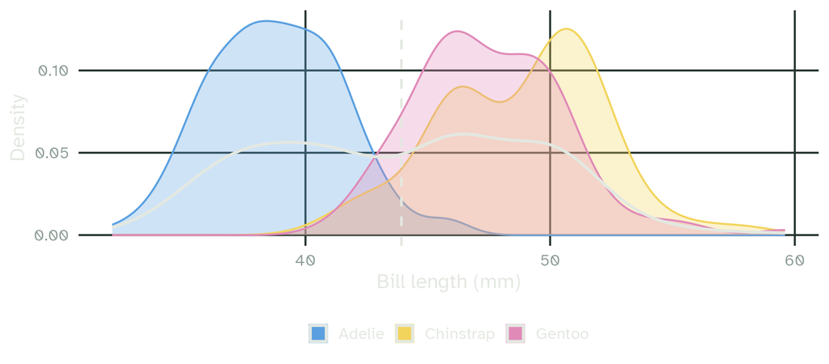

The overall mean (43.9 mm) sits in a dip: few penguins actually have a bill that long. The distribution has three species in it.

## Skewed data: reaction times

Reaction times cannot be negative, and some responses are very slow:

```r
set.seed(3)
rt <- tibble(rt = rlnorm(2000, meanlog = log(600), sdlog = 0.35))
rt |> summarise(mean = mean(rt), median = median(rt))
```

```
# A tibble: 1 × 2
   mean median
  <dbl>  <dbl>
1  636.   602.
```

## Skewed data: reaction times

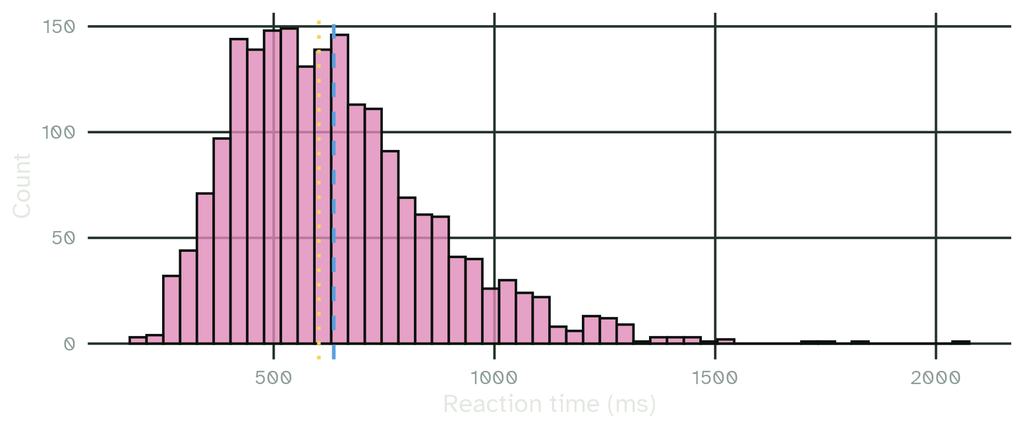

A long right tail pulls the mean (dashed) away from the median (dotted).

## Outliers

One participant fell asleep on one trial:

```r
set.seed(7)
rts <- round(rlnorm(40, meanlog = log(600), sdlog = 0.25))
rts_sleepy <- c(rts, 5000)

tibble(data   = c("40 trials", "40 trials + one 5000 ms"),
       mean   = c(mean(rts), mean(rts_sleepy)),
       median = c(median(rts), median(rts_sleepy)))
```

```
# A tibble: 2 × 3
  data                     mean median
  <chr>                   <dbl>  <dbl>
1 40 trials                665.   626.
2 40 trials + one 5000 ms  770.   628
```

The mean moves by more than 100 ms. The median barely moves: it is robust.

## Discussion

Here we know that the participant fell asleep. In real data, a 5,000 ms response usually comes with no explanation.

- Would you remove it? How would you decide which responses are too slow?
- Why does it matter whether you decide before or after looking at the results?

## Mode

The mode is the most frequent value. It is used in **categorical** distributions.

With `count()` from last week:

```r
penguins |> count(island) |> slice_max(n)
```

```
# A tibble: 1 × 2
  island     n
  <fct>  <int>
1 Biscoe   168
```

```r
words <- tibble(word = c("the", "cat", "saw", "the", "dog", "and", "the", "bird"))
words |> count(word, sort = TRUE) |> head(3)
```

```
# A tibble: 3 × 2
  word      n
  <chr> <int>
1 the       3
2 and       1
3 bird      1
```

## Mode: a trap

R has a function called `mode()`, but it does not compute the mode:

```r
mode(c("Hello", "Hello", "Goodbye"))
```

```
[1] "character"
```

It returns the storage type. If you need a function, write your own:

```r
find_mode <- function(x) {
  u <- unique(x)
  tab <- tabulate(match(x, u))
  u[tab == max(tab)]
}
find_mode(c("Hello", "Hello", "Goodbye", "Hello", "Penguin", "Dog", "Mountain"))
```

```
[1] "Hello"
```

# Spread

`Did you know:` when their home dries out, tardigrades lose their body water, curl up and enter cryptobiosis, a deep sleep. They can revive years later, when water returns.

*Sources: National Geographic; ScienceDaily*

## Same centre, different spread

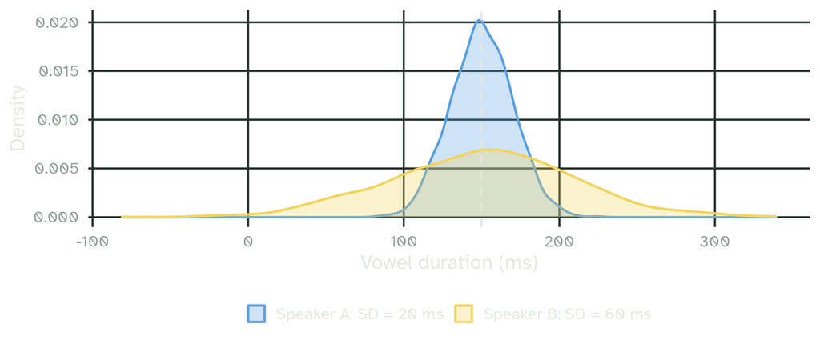

Both speakers have a mean of 150 ms. Speaker B is far less consistent.

## `sd()`

The standard deviation measures how spread out the values are around the mean: roughly, how far a typical value is from it.

s = √( Σ (xᵢ − x)² / (n − 1) )

```r
x <- c(4, 8, 15, 16, 23, 42)
sqrt(sum((x - mean(x))^2) / (length(x) - 1))
```

```
[1] 13.49074
```

```r
sd(x)
```

```
[1] 13.49074
```

```r
var(x)       # the variance is the SD squared
```

```
[1] 182
```

## `sd()`

```r
penguins |>
  summarise(mean_bill = mean(bill_length_mm, na.rm = TRUE),
            sd_bill   = sd(bill_length_mm, na.rm = TRUE))
```

```
# A tibble: 1 × 2
  mean_bill sd_bill
      <dbl>   <dbl>
1      43.9    5.46
```

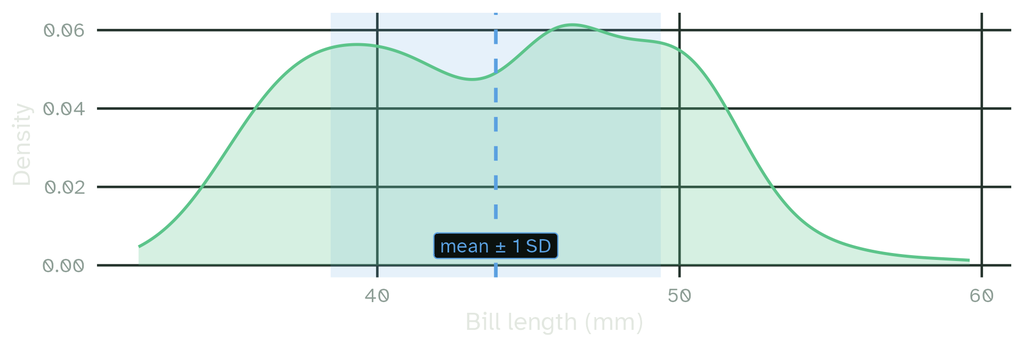

## `mad()`

The median absolute deviation (MAD) is the robust partner of the SD: the median distance of the values from their median.

| Step | Values |  |
| --- | --- | --- |
| 1. The data, sorted | 1, 1, 2, **2**, 4, 6, 9 | median = 2 |
| 2. Distance of each value from 2 | 1, 1, 0, 0, 2, 4, 7 |  |
| 3. The same distances, sorted | 0, 0, 1, **1**, 2, 4, 7 | MAD = 1 |

## `mad()` in R

```r
x <- c(1, 1, 2, 2, 4, 6, 9)
mad(x, constant = 1)
```

```
[1] 1
```

```r
mad(x)
```

```
[1] 1.4826
```

By default, `mad()` multiplies the result by 1.4826. With normal data, this makes the MAD estimate the SD, so the two are comparable.

```r
c(sd = sd(rts), mad = mad(rts))                    # 40 trials
```

```
      sd      mad
187.2306 150.4839
```

```r
c(sd = sd(rts_sleepy), mad = mad(rts_sleepy))      # + one 5000 ms trial
```

```
      sd      mad
701.8433 158.6382
```

## `mad()`

```r
penguins |>
  summarise(median_bill = median(bill_length_mm, na.rm = TRUE),
            mad_bill    = mad(bill_length_mm, na.rm = TRUE))
```

```
# A tibble: 1 × 2
  median_bill mad_bill
        <dbl>    <dbl>
1        44.4     7.04
```

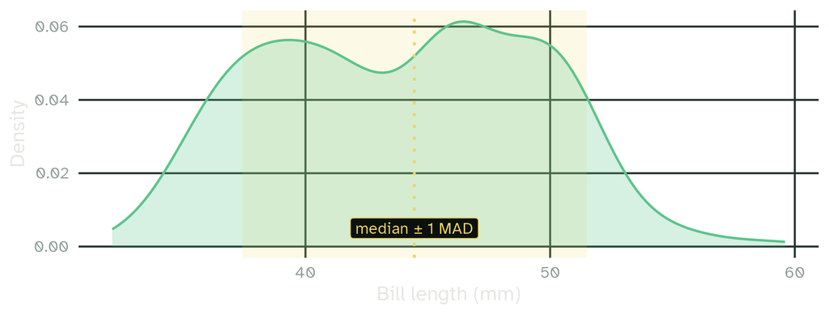

## `range()`

`range()` returns the smallest and the largest value. The distance between them is what statisticians call the range.

```r
range(penguins$bill_length_mm, na.rm = TRUE)
```

```
[1] 32.1 59.6
```

```r
diff(range(penguins$bill_length_mm, na.rm = TRUE))
```

```
[1] 27.5
```

The range depends on two values only, the most extreme ones. One outlier changes it completely.

## Quantiles / Quartiles

Quantiles cut the sorted values into groups of equal size. Quartiles cut them into four quarters:

```r
quantile(penguins$bill_length_mm, na.rm = TRUE)
```

```
    0%    25%    50%    75%   100%
32.100 39.225 44.450 48.500 59.600
```

```r
IQR(penguins$bill_length_mm, na.rm = TRUE)     # 75% minus 25%
```

```
[1] 9.275
```

The median is the 50% quantile. The IQR holds the middle half of the data.

## `summary()`

Most of today in one line:

```r
summary(penguins$bill_length_mm)
```

```
   Min. 1st Qu.  Median    Mean 3rd Qu.    Max.    NA's
  32.10   39.23   44.45   43.92   48.50   59.60       2
```

It works on a whole data frame too: try `summary(penguins)`.

## Boxplots draw the quartiles

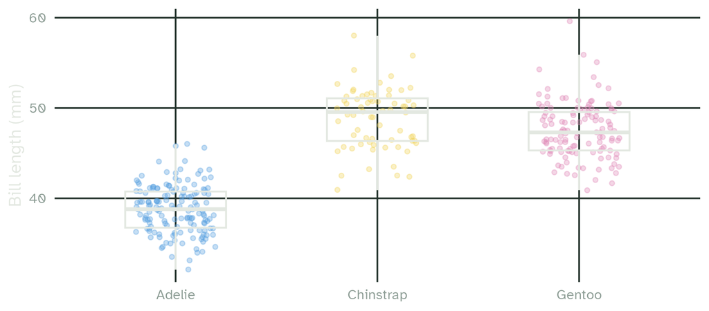

Box: 25% to 75% (the IQR). Line: the median. Whiskers: to the furthest point within 1.5 × IQR of the box. Dots: every penguin.

# `group_by` and `summarise`

`Did you know:` in 2007, dried tardigrades flew into orbit on the FOTON-M3 mission and were exposed to open space: vacuum, cosmic rays and solar UV over 1,000 times stronger than on Earth. Most survived the vacuum, a few even the full UV, and the survivors reproduced normally.

*Sources: Jönsson et al. (2008), Current Biology; ScienceDaily*

## Summaries per group

Until now, we have summarised one distribution at a time.

Usually we want the same summary for each group: `bill_length_mm` for each species separately.

The bad way to do it:

```r
Adelie    <- filter(penguins, species == "Adelie")
Gentoo    <- filter(penguins, species == "Gentoo")
Chinstrap <- filter(penguins, species == "Chinstrap")
mean(Adelie$bill_length_mm, na.rm = TRUE)
```

```
[1] 38.79139
```

```r
mean(Gentoo$bill_length_mm, na.rm = TRUE)
```

```
[1] 47.50488
```

```r
mean(Chinstrap$bill_length_mm, na.rm = TRUE)
```

```
[1] 48.83382
```

## The good way

Last week: `group_by()` + `summarise()`, or `summarise(.by = )`

```r
penguins |>
  drop_na(bill_length_mm) |>
  summarise(n      = n(),
            mean   = mean(bill_length_mm),
            sd     = sd(bill_length_mm),
            median = median(bill_length_mm),
            IQR    = IQR(bill_length_mm),
            .by    = species)
```

```
# A tibble: 3 × 6
  species       n  mean    sd median   IQR
  <fct>     <int> <dbl> <dbl>  <dbl> <dbl>
1 Adelie      151  38.8  2.66   38.8  4
2 Gentoo      123  47.5  3.08   47.3  4.25
3 Chinstrap    68  48.8  3.34   49.6  4.73
```

One row per species, one column per summary, no copies of the data.

## Grouping by two variables

```r
penguins |>
  drop_na(sex) |>
  group_by(species, sex) |>
  summarise(mean_bill = mean(bill_length_mm),
            median_bill = median(bill_length_mm))
```

```
`summarise()` has regrouped the output.
ℹ Summaries were computed grouped by species and sex.
ℹ Output is grouped by species.
ℹ Use `summarise(.groups = "drop_last")` to silence this message.
ℹ Use `summarise(.by = c(species, sex))` for per-operation grouping
  (`?dplyr::dplyr_by`) instead.
```

```
# A tibble: 6 × 4
# Groups:   species [3]
  species   sex    mean_bill median_bill
  <fct>     <fct>      <dbl>       <dbl>
1 Adelie    female      37.3        37
2 Adelie    male        40.4        40.6
3 Chinstrap female      46.6        46.3
4 Chinstrap male        51.1        51.0
# ℹ 2 more rows
```

The message: the result is still grouped by species. Either add `.groups = "drop"`, `ungroup()` it, or use `.by = c(species, sex)`, which never leaves groups behind.

## `group_by()` or `.by`?

Use `group_by()` when several steps in a row should work per group, and `ungroup()` when you are done, before you save the result.

Use `.by` when only one step needs the groups. Nothing stays grouped afterwards, so there is nothing to forget.

## Many columns at once: `across()`

From last week: `across(columns, function)`

```r
penguins |>
  summarise(across(ends_with("_mm"),
                   list(mean = \(x) mean(x, na.rm = TRUE),
                        sd   = \(x) sd(x, na.rm = TRUE))),
            .by = species) |>
  select(species, starts_with("bill_length"))
```

```
# A tibble: 3 × 3
  species   bill_length_mm_mean bill_length_mm_sd
  <fct>                   <dbl>             <dbl>
1 Adelie                   38.8              2.66
2 Gentoo                   47.5              3.08
3 Chinstrap                48.8              3.34
```

`list(mean = ..., sd = ...)` applies two functions to each column, and adds `_mean` and `_sd` to the names.

## Plotting group summaries

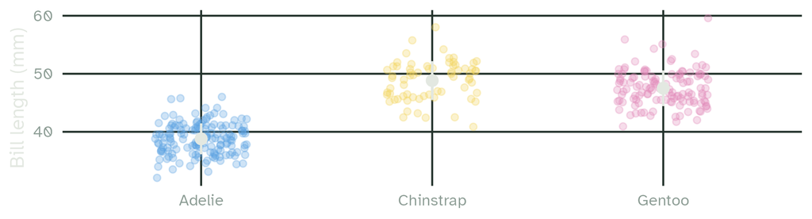

```r
bill_summary <- penguins |>
  drop_na(bill_length_mm) |>
  summarise(mean = mean(bill_length_mm), sd = sd(bill_length_mm), .by = species)

ggplot(drop_na(penguins, bill_length_mm), aes(x = species, y = bill_length_mm)) +
  geom_jitter(aes(colour = species), width = 0.2, alpha = 0.3) +
  geom_pointrange(data = bill_summary, colour = "#e3e8e1", linewidth = 1, size = 0.8,
                  aes(y = mean, ymin = mean - sd, ymax = mean + sd)) +
  labs(x = NULL, y = "Bill length (mm)") + theme(legend.position = "none")
```

Points: every penguin. White: mean ± 1 SD per species.

## Reporting descriptives

In R Markdown, numbers in your text can come straight from R:

```r
gentoo <- filter(bill_summary, species == "Gentoo")
```

```markdown
Gentoo bills were `r round(gentoo$mean, 1)` mm long on average
(SD = `r round(gentoo$sd, 1)`).
```

becomes

> Gentoo bills were 47.5 mm long on average (SD = 3.1).

If the data change, the text updates itself, so you never copy numbers by hand.

## Summary

- A summary is a simplified map of a distribution
- Centre: `mean()` (sensitive), `median()` (robust), mode with `count()`
- Spread: `sd()` (sensitive), `mad()` and `IQR()` (robust), `range()`, `quantile()`
- Always plot the data: skew, outliers and several peaks hide behind one number
- Per group: `summarise()` with `.by` or `group_by()`; many columns with `across()`

## Slides and code

[figure not shown]

These slides

mcanzi.de/ws26_statistics/03_descriptive_statistics.html

Code, data and all lectures

github.com/mcanzi/ws26_statistics